# Social Engagement Analysis

This report explores patterns in social and volunteering engagement in Singapore. The dataset of 3076 respondents used contains survey results from the MCCY (Ministry of Culture, Community and Youth) Social Values Survey on attitudes and actions that inform Singaporeans’ desire to build social capital.

## Response Variable: Social score as measure of engagement

Social score is defined as the sum of the values of the different variations of variables socialinvolve and volunteerdonate (columns 7 to 17). 1 represents Yes and 0 represents No.

social_involve:

1. Participation in any social groups - Sports related groups (e.g. soccer, running, badminton etc)
2. Participation in any social groups - Arts and Cultural groups (e.g. dance groups, book club, band etc)
3. Participation in any social groups - Community groups (e.g. resident community etc)
4. Participation in any social groups - Welfare & Self-Help groups (e.g. non-profit organisations)
5. Participation in any social groups - Religious groups
6. Participation in any social groups - Interest & Hobby groups

volunteerdonate:

1. Participation in any volunteering/donating - Volunteered time at community centers / resident communities / places of worship / other charitable organisations
2. Participation in any volunteering/donating - Donated money to charitable causes
3. Participation in any volunteering/donating - Donated goods / services to charitable causes (e.g. food, toy)
4. Participation in any volunteering/donating - Volunteered time for community projects initiated by friends, family, neighbours
5. Participation in any volunteering/donating - Helped a neighbor or others in my community who were in need

## Numerical and Graphical Summary of Social Score

Social scores are generally low with the median being 1 and mean being 1.387. Minimum is 0 and maximum is 11.

```
##    Min. 1st Qu.  Median    Mean 3rd Qu.    Max.
##   0.000   0.000   1.000   1.387   2.000  11.000
```

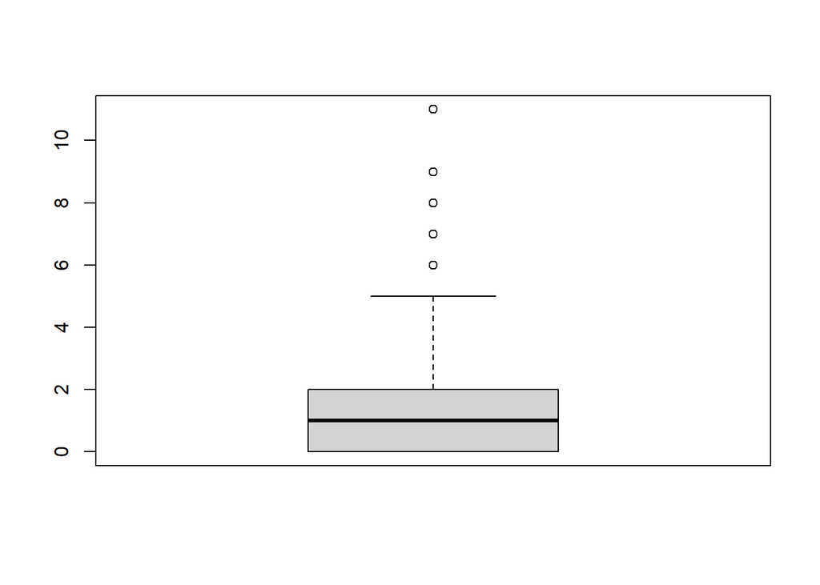

## Social Engagement Breakdown

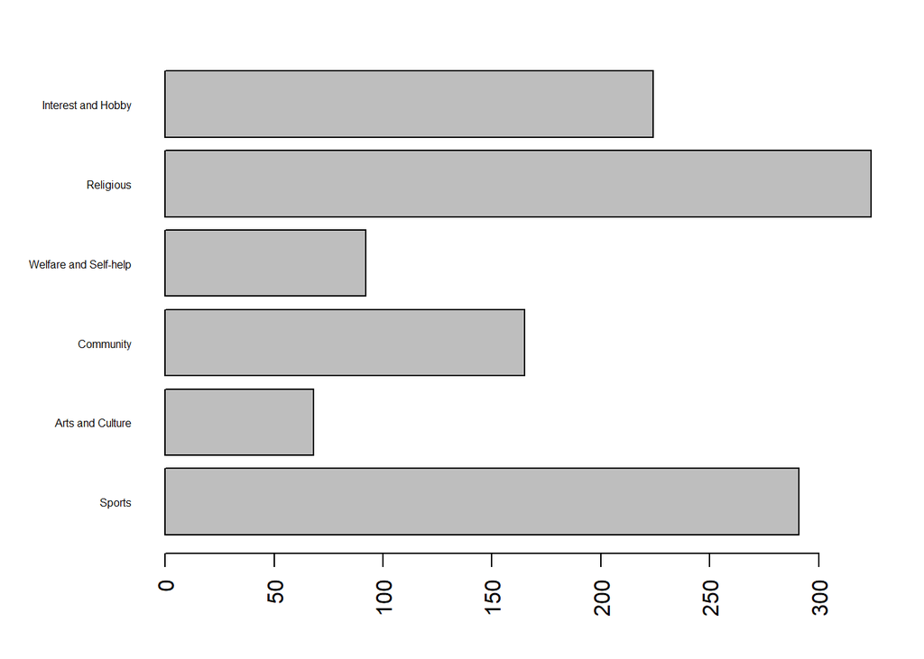

Majority of respondents participate in Religious or Sports groups. Arts and Culture and Welfare and Self-help groups have the least frequent participation.

## Volunteering Breakdown

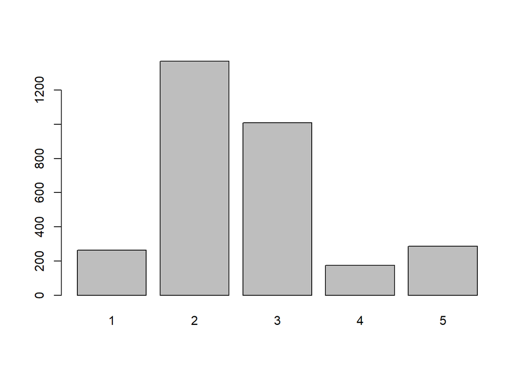

Labels:

1 - Volunteered time at community centers / resident communities / places of worship / other charitable organisations

2 - Donated money to charitable causes

3 - Donated goods / services to charitable causes (e.g. food, toy)

4 - Volunteered time for community projects initiated by friends, family, neighbours

5 - Helped a neighbor or others in my community who were in need

Majority of respondents donated money and goods and services to charitable causes. There is a significantly lower participation in volunteering time in organisations and projects, and helping others in the community.

## Exploring Association of Demographic Variables with Social Score

### 1. Gender

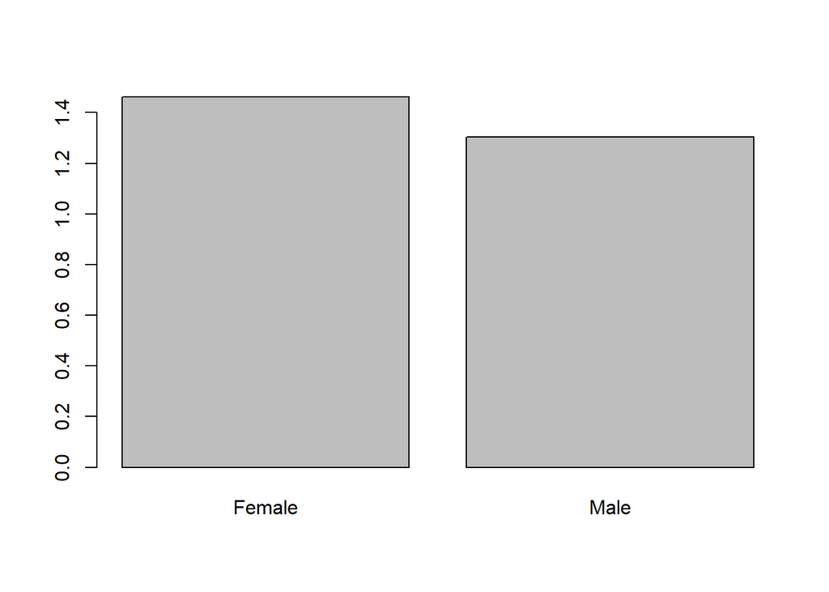

The plot shows that females have a slightly higher mean social score than males. There are 1612 females and 1464 males.

### 2. Age

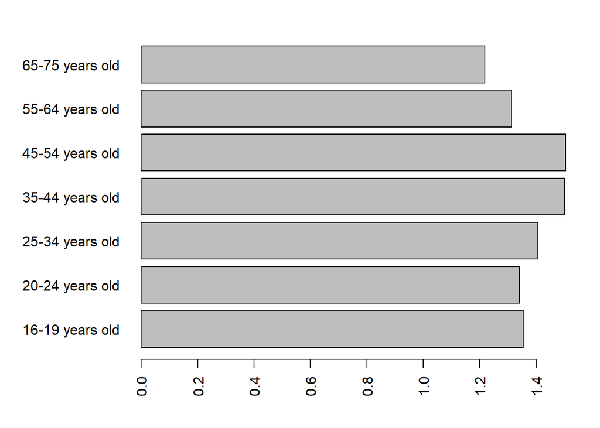

Those 35-44 years old and 45-54 years old have the highest mean social score. The table below shows the number of respondents belonging to each age group.

```
##
## 16-19 years old 20-24 years old 25-34 years old 35-44 years old 45-54 years old
##             268             211             512             536             545
## 55-64 years old 65-75 years old
##             542             462
```

### 3. Monthly Household Income

```
##
##    Below S$1,000    S$1,000-2,000  S$2,001-S$3,000  S$3,001-S$4,000
##               96              222              226              261
##  S$4,001-S$5,000  S$5,001-S$6,000  S$6,001-S$7,000  S$7,001-S$8,000
##              267              208              139              136
##  S$8,001-S$9,000 S$9,001-S$10,000  $10,001-$11,000  $11,001-$12,000
##               97               82              168               65
##  $12,001-$13,000  $13,001-$14,000  $14,001-$15,000  $15,001-$20,000
##               42               35               44               54
##    Above $20,000        No income
##               86              125
```

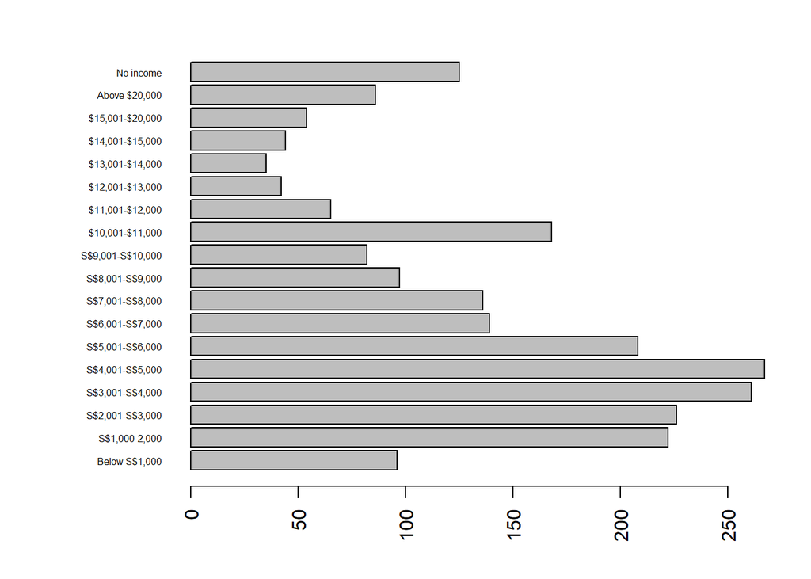

The above is a bar chart representation of the frequency of each income group.

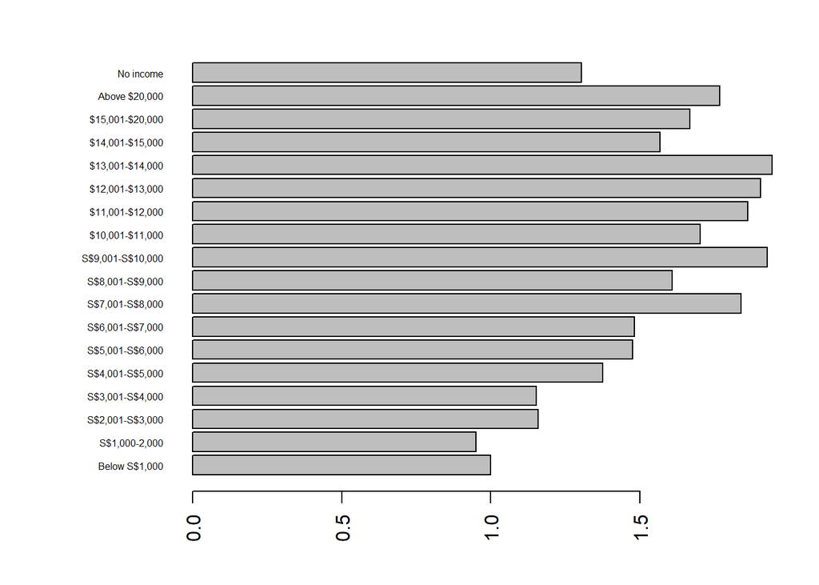

The above is a plot of mean social score by household income. Social score generally increases with increasing household income.

### 4. Dwelling

Bar chart of the frequency of housing types:

```
##
##                       Dormitory                    HDB 1-2 room
##                               1                             190
##                      HDB 3 room                      HDB 4 room
##                             557                            1096
##          HDB 5 room / Executive                 Landed property
##                             606                             208
##                           Other Private apartment / Condominium
##                               1                             417
```

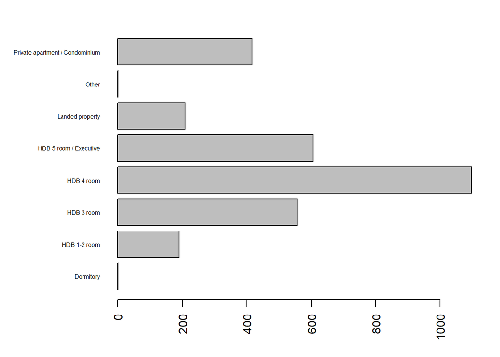

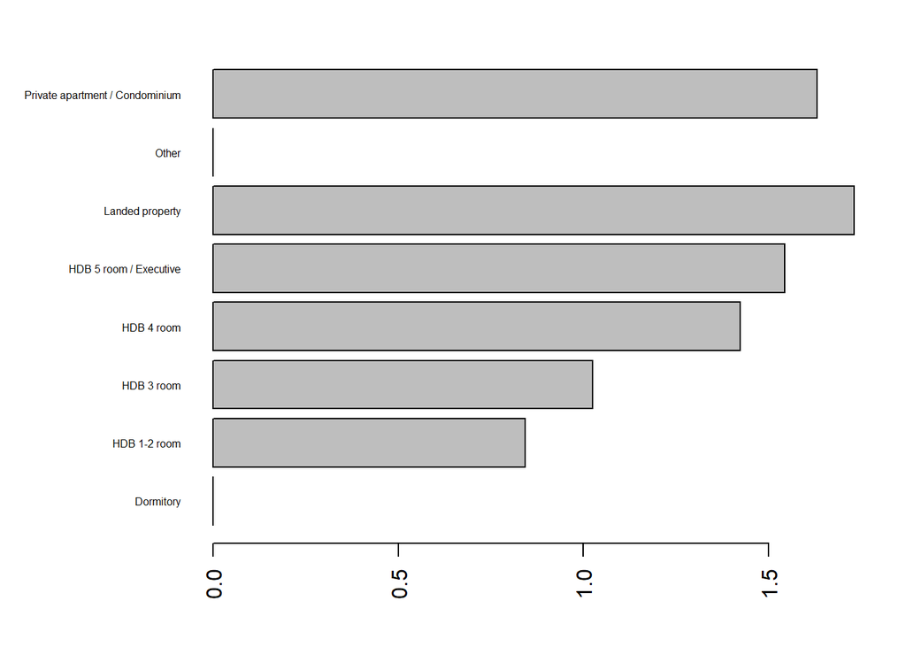

Plot of mean social score against housing type. Social score generally increases with increasing average price of housing.

### 5. Education

Table and bar chart representations of the frequency of the different education levels:

```
##
##                     No formal education                   Primary school / PSLE
##                                      68                                     471
## Secondary/ high school / "O / N" Levels           Technical / vocational school
##                                     920                                     181
##                   Polytechnic / diploma     Junior College / Pre-U / "A" Levels
##                                     534                                     138
##                     University / degree                    Post graduate degree
##                                     619                                     143
##                                   Other
##                                       2
```

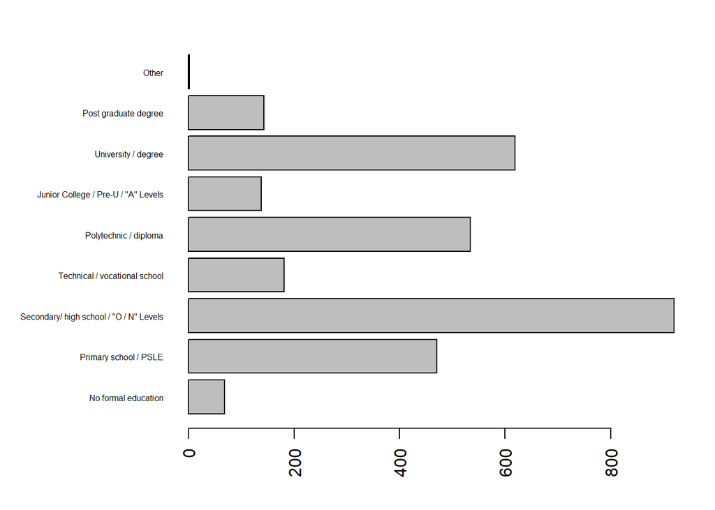

Most respondents have secondary/high school/O/N Levels or University/degree as their highest education level. Least respondents have No formal education, Junior College/Pre U/A Levels, Postgraduate or Other as their highest education level.

Bar chart of average social score per education level:

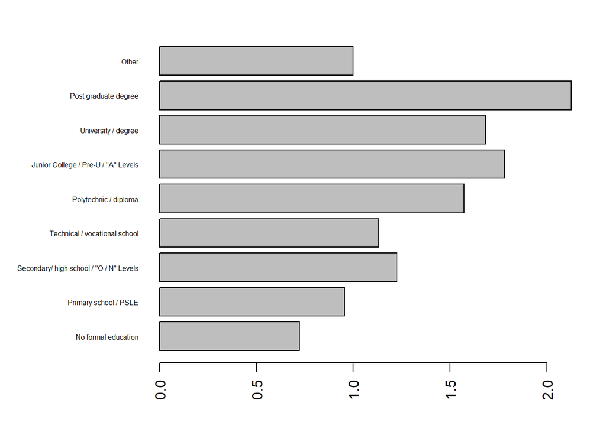

## Chi Square Test: Are people with certain social networks more likely to volunteer at organisations?

(Defined as: Volunteered time at community centers / resident communities / places of worship / other charitable organisations)

Variable: Have close friends of different nationality

```
##
##  Pearson's Chi-squared test with Yates' continuity correction
##
## data:  table_data
## X-squared = 13.127, df = 1, p-value = 0.0002911
```

Variable: Have close friends of different ethnicity

```
##
##  Pearson's Chi-squared test with Yates' continuity correction
##
## data:  table_data
## X-squared = 5.7439, df = 1, p-value = 0.01655
```

Variable: Have close friends of different education

```
##
##  Pearson's Chi-squared test with Yates' continuity correction
##
## data:  table_data
## X-squared = 0.44075, df = 1, p-value = 0.5068
```

Variable: Have close friends of different income

```
##
##  Pearson's Chi-squared test with Yates' continuity correction
##
## data:  table_data
## X-squared = 2.0146, df = 1, p-value = 0.1558
```

Variable: Have close friends of different religion

```
##
##  Pearson's Chi-squared test with Yates' continuity correction
##
## data:  table_data
## X-squared = 9.0641, df = 1, p-value = 0.002607
```

Variable: Have close Singaporean friends

```
##
##  Pearson's Chi-squared test
##
## data:  table_data
## X-squared = 1.5246, df = 2, p-value = 0.4666
```

There is significant association between having friends of different nationalities, ethnicities or religion, and volunteering at organisations (p < 0.05).

There is no significant association between education level, income or having close Singaporean friends and volunteering at organisations (p > 0.05).

Among the network types examined, having friends of different nationalities or religions shows the strongest association with volunteering at organisations.

Among the network types examined, having close Singaporean friends or friends of different education levels show the weakest association with volunteering at organisations.

## T test: Is there significant association between Gender and Social engagement?

```
## [1] 1.974359
```

```
## [1] 1.968378
```

```
##
##  Welch Two Sample t-test
##
## data:  social_score by gender
## t = 3.121, df = 3046.6, p-value = 0.001819
## alternative hypothesis: true difference in means between group Female and group Male is not equal to 0
## 95 percent confidence interval:
##  0.05881024 0.25758388
## sample estimates:
## mean in group Female   mean in group Male
##             1.462159             1.303962
```

Assumptions:

1. Each observation is independent.
2. Normality: With large sample size of 1612 females and 1464 males, the Central Limit Theorem ensures the sampling distribution of the mean is roughly normal.
3. Equality of variances: Variance for female social scores is 1.974359 and that for males is 1.968378 The ratio is 1.003. They are effectively equal.

From the t-test, there is significant evidence that the mean of females’ social scores is higher than that of males.